# Archetype analysis of Darwin’s finches

## Useful libraries (optional)

Remove the following two lines if you want to use other tools for plotting. You might have to install ggplot2 and ggfortify using `install.package(ggplot2)` and`install.package(ggfority)`. You can also use something else to plot. In particular, [autoplot](https://cran.r-project.org/web/packages/ggfortify/vignettes/plot_pca.html) (available through ggplot and ggfortify might be useful to look at the PCA results.)

```r
library(ggplot2)
library(ggfortify)
```

## Tasks

Follow the following steps to perform an archetype analysis of the finch data.

- Read the data from `data/finches.csv` (`read.csv` should do the trick).
- Plot the data. Can you already infer archetypes? It is challenging in 5 dimensions, right?
- Perform a principal component analysis (PCA).
  - `princomp` is recommended.
  - If you need a refresher on PCA, check out this interactive explanation: https://setosa.io/ev/principal-component-analysis/.
- Determine how much of the variance in the data is captured by the individual principal components.
- Plot the first two principle components. How many archetypes can you identify in the plot?
- Look at the feature loadings (`pca_result$loadings`). You can also `autoplot` or `biplot` to generate a [biplot](https://en.wikipedia.org/wiki/Biplot) of the components and loadings. What are the contributions of the features to the first two principal components?
- Compute the convex hull (`chull` is recommended) and highlight it in the PCA plot.
- Bonus points: based on the points in the convex hull, determine the triangle with the largest surface (spanned by three points in the convex hull).

## Reference solution

### Load the data.

```r
finches <- read.csv("~/Dev/r-studio-binder/data/finches.csv", header=TRUE)
```

### Plot the data

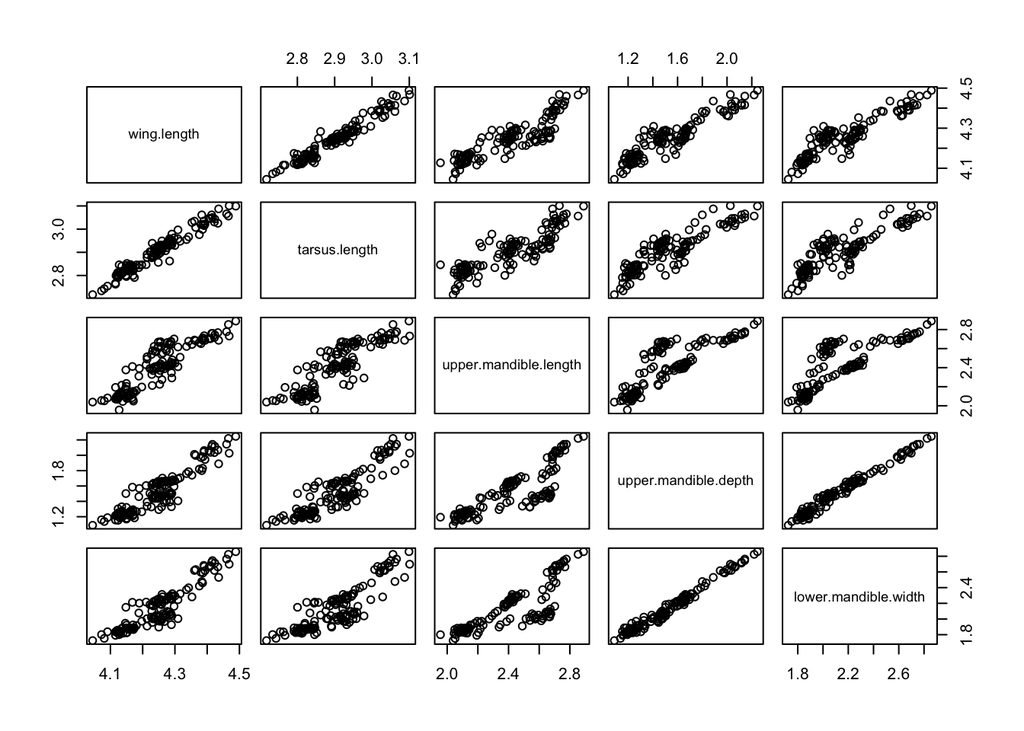

### PCA

```r
pca <- princomp(finches, cor=TRUE, scores=TRUE) # cor=TRUE => scale & center
```

Plot the variance captured by the 5 principle componets.

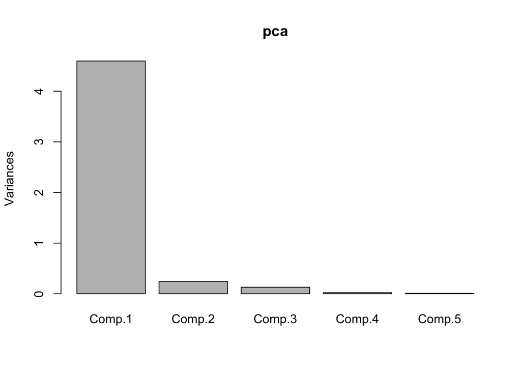

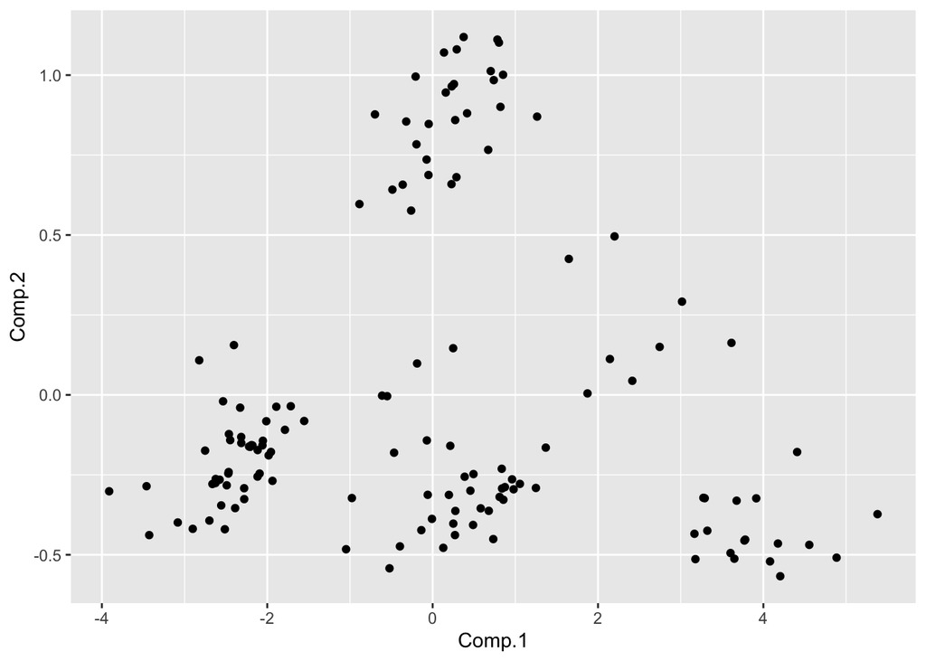

```r
pca$loadings
```

```
##
## Loadings:
##                       Comp.1 Comp.2 Comp.3 Comp.4 Comp.5
## wing.length            0.459  0.110  0.364  0.772  0.221
## tarsus.length          0.449  0.234  0.639 -0.547 -0.190
## upper.mandible.length  0.428  0.668 -0.604
## upper.mandible.depth   0.452 -0.445 -0.210 -0.300  0.681
## lower.mandible.width   0.447 -0.538 -0.224  0.108 -0.670
##
##                Comp.1 Comp.2 Comp.3 Comp.4 Comp.5
## SS loadings       1.0    1.0    1.0    1.0    1.0
## Proportion Var    0.2    0.2    0.2    0.2    0.2
## Cumulative Var    0.2    0.4    0.6    0.8    1.0
```

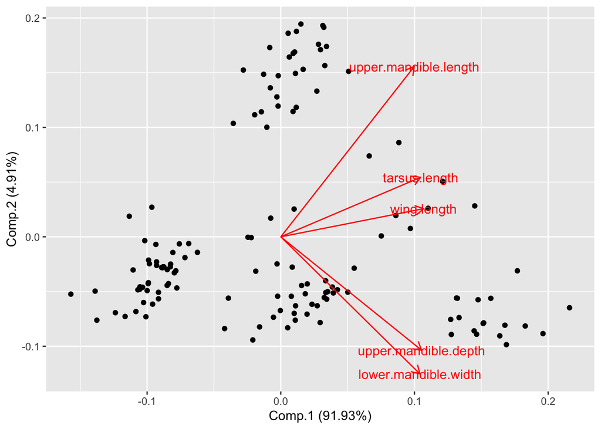

```r
autoplot(pca, loadings = TRUE, loadings.label = TRUE)
```

### Compute the convex hull and highlight it in the plot

```r
hull <- chull(pca_df$Comp.1, pca_df$Comp.2)
hull
```

```
##  [1]  10  80  75  94 114 113 117 127  62 130 125  60
```

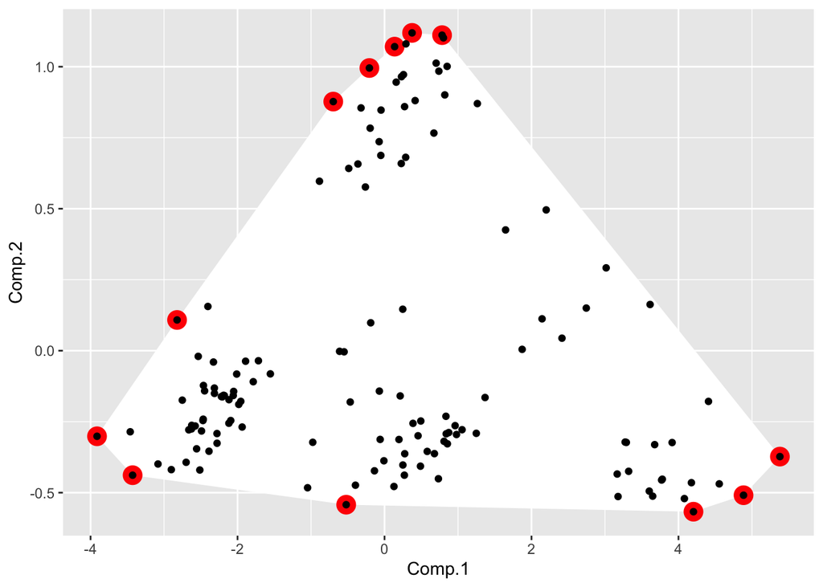

```r
pca_df <- data.frame(pca$scores)
ggplot(data=pca_df, aes(x=Comp.1, y=Comp.2)) +
  geom_polygon(data=pca_df[hull, ], fill='white') +
  geom_point(data=pca_df[hull, ], colour="red", size=5) +
  geom_point()
```

### Bonus points: in the convex hull, find the three points that span the triangle with the largest area and highlight it in the PCA plot

```r
winner <- 0
area <- 0
for (i in hull){
  for (j in hull){
    for (k in hull)
      ax = pca_df$Comp.1[i]
      ay = pca_df$Comp.2[i]
      bx = pca_df$Comp.1[j]
      by = pca_df$Comp.2[j]
      cx = pca_df$Comp.1[k]
      cy = pca_df$Comp.2[k]
      area_new <- abs((ax * (by - cy) + bx * (cy - ay) + cx * (ay + by)) / 2)
      if (area_new >= area) {
        print(area_new)
        area <- area_new
        winner <- c(i, j, k)
      }
  }
}
```

```
## [1] 0.2920978
## [1] 1.078508
## [1] 1.763069
## [1] 5.193567
## [1] 7.029989
```

```r
print("The three points in the convex hull that correspond to the triangle with largest area")
```

```
## [1] "The three points in the convex hull that correspond to the triangle with largest area"
```

```r
print(winner)
```

```
## [1]  10 114  60
```

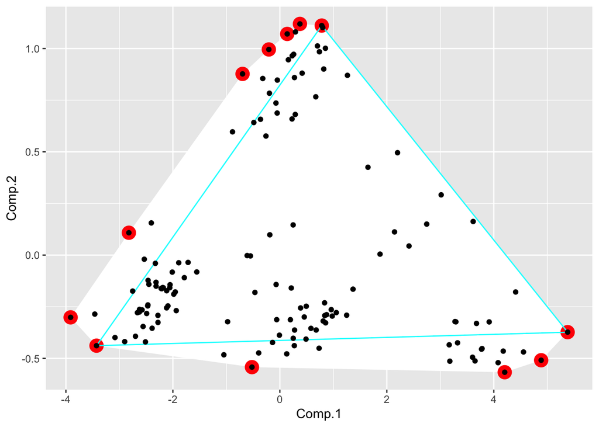

```r
pca_df <- data.frame(pca$scores)
ggplot(data=pca_df, aes(x=Comp.1, y=Comp.2)) +
  geom_polygon(data=pca_df[hull, ], fill='white') +
  geom_point(data=pca_df[hull, ], colour="red", size=5) +
  geom_path(data=pca_df[append(winner, winner[1]), ], colour="cyan") +
  geom_point()
```